# Project RMD

Group 2

11/30/2020

# Group 2 Project Analysis

Begin by Loading in all the data, and plotting a linear model with all the variables. Make sure to set your working directory. All project code/csv/excel/etc… files can be found at https://github.com/Rmcortez12/stat-learning. Also do some preliminary scatter plot analysis. We’re fairly certain all the relationships are linear.

```r
library(MASS)
library(car)
#Load Data

setwd("d:/UTSA/Fall2020/DataMining/Project/stat-learning") # set working directory
df = read.csv('FinalDF.csv') # read in raw csv data


df$Age15_19 = as.factor(df$Age15_19)
df$Age20_24 = as.factor(df$Age20_24)
df$Age25_29 = as.factor(df$Age25_29)
df$Age30_34 = as.factor(df$Age30_34)
df$Age35_39 = as.factor(df$Age35_39)
df$Age40_44 = as.factor(df$Age40_44)
df$Age45_49 = as.factor(df$Age45_49)
df$Age50_54 = as.factor(df$Age50_54)
df$Age55_59 = as.factor(df$Age55_59)
df$Age60_64 = as.factor(df$Age60_64)

df$Australia = as.factor(df$Australia)
df$Belarus = as.factor(df$Belarus)
df$Belgium = as.factor(df$Belgium)
df$Canada = as.factor(df$Canada)
df$Denmark = as.factor(df$Denmark)
df$Finland = as.factor(df$Finland)
df$France = as.factor(df$France)
df$Germany = as.factor(df$Germany)
df$India = as.factor(df$India)
df$Ireland = as.factor(df$Ireland)
df$Japan = as.factor(df$Japan)
df$Mexico = as.factor(df$Mexico)
df$NZ = as.factor(df$NZ)
df$Russia = as.factor(df$Russia)
df$Singapore = as.factor(df$Singapore)
df$Spain = as.factor(df$Spain)
df$Sweden = as.factor(df$Sweden)
df$Switzerland = as.factor(df$Switzerland)
df$Ukraine = as.factor(df$Ukraine)
df$UK= as.factor(df$UK)
df$US= as.factor(df$US)

#update belarus temps
df$difference[163] = 10
df$difference[177] = 10
df$difference[224] = 10
df$difference[255] = 10
df$difference[266] = 10

exclude_vars <- names(df) %in% c("Runner" ,"Max", "Min", "Avg" ,"Age", "Team", "X" )
df.filtered <-df[,!exclude_vars]

#full model
fit.lm = lm(Yards ~ .,data = df.filtered)
summary(fit.lm)
```

```
##
## Call:
## lm(formula = Yards ~ ., data = df.filtered)
##
## Residuals:
##     Min      1Q  Median      3Q     Max
## -9.6246 -2.7092 -0.4727  2.0742 20.6792
##
## Coefficients: (4 not defined because of singularities)
##                   Estimate Std. Error t value Pr(>|t|)
## (Intercept)       8.369682   9.994019   0.837 0.403246
## rate_sd1         -0.015494   0.008514  -1.820 0.070165 .
## rate_sd2         -0.013292   0.009996  -1.330 0.184984
## rate_sd3         -0.014062   0.009410  -1.494 0.136539
## rate_sd4         -0.013439   0.006149  -2.186 0.029909 *
## avg_rate_q1      -0.006303   0.013514  -0.466 0.641391
## avg_rate_q2      -0.025685   0.023974  -1.071 0.285190
## avg_rate_q3       0.009906   0.022454   0.441 0.659521
## avg_rate_q4      -0.034165   0.012658  -2.699 0.007497 **
## median_rate_q1    0.006661   0.009550   0.698 0.486204
## median_rate_q2   -0.008147   0.015171  -0.537 0.591805
## median_rate_q3    0.017081   0.012476   1.369 0.172377
## median_rate_q4   -0.010210   0.009110  -1.121 0.263652
## sd_q1            -0.137555   0.024526  -5.609 6.15e-08 ***
## sd_q2            -0.026478   0.021825  -1.213 0.226370
## sd_q3            -0.138141   0.021807  -6.335 1.34e-09 ***
## sd_q4            -0.068778   0.015648  -4.395 1.73e-05 ***
## avg_sec_q1        0.001007   0.015296   0.066 0.947585
## avg_sec_q2        0.013273   0.018328   0.724 0.469743
## avg_sec_q3        0.010941   0.015862   0.690 0.491082
## avg_sec_q4       -0.006063   0.015291  -0.396 0.692139
## median_sec_q1     0.002121   0.011752   0.180 0.856950
## median_sec_q2     0.004377   0.011890   0.368 0.713153
## median_sec_q3    -0.003662   0.010291  -0.356 0.722324
## median_sec_q4     0.004052   0.009544   0.425 0.671588
## range_q1          0.066573   0.008203   8.116 3.51e-14 ***
## range_q2          0.021600   0.007355   2.937 0.003671 **
## range_q3          0.056787   0.007771   7.308 5.07e-12 ***
## range_q4          0.031852   0.005955   5.349 2.23e-07 ***
## rate_sd_diff_4_1        NA         NA      NA       NA
```

[output cut: 27 more lines]

```
## Age35_391         4.460332   3.804288   1.172 0.242297
## Age40_441         3.529316   3.824158   0.923 0.357079
## Age45_491         4.777580   3.814015   1.253 0.211680
## Age50_541         3.002512   3.861911   0.777 0.437726
## Age55_591         1.356389   4.204326   0.323 0.747294
## Age60_641               NA         NA      NA       NA
## AvgSeconds       -0.035169   0.041393  -0.850 0.396455
## MaxSeconds        0.001561   0.006051   0.258 0.796706
## MinSeconds        0.010301   0.003066   3.360 0.000920 ***
## ---
## Signif. codes:  0 '***' 0.001 '**' 0.01 '*' 0.05 '.' 0.1 ' ' 1
##
## Residual standard error: 4.944 on 218 degrees of freedom
## Multiple R-squared:  0.8314, Adjusted R-squared:  0.7842
## F-statistic: 17.62 on 61 and 218 DF,  p-value: < 2.2e-16
```

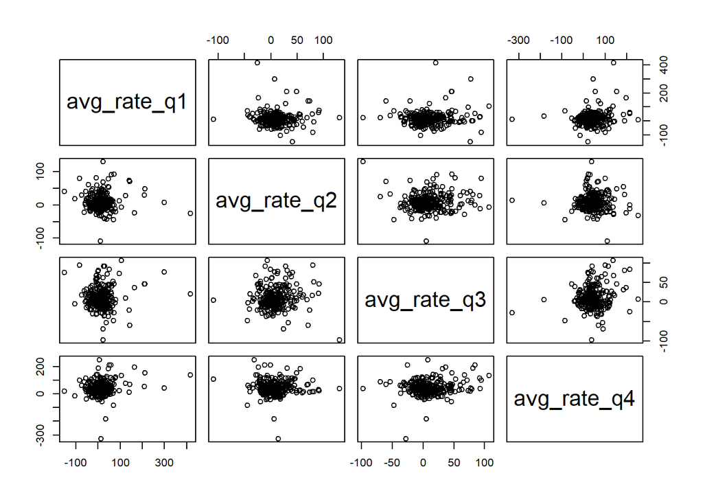

```r
pairs(df[,grepl("avg_rate",names(df))])
```

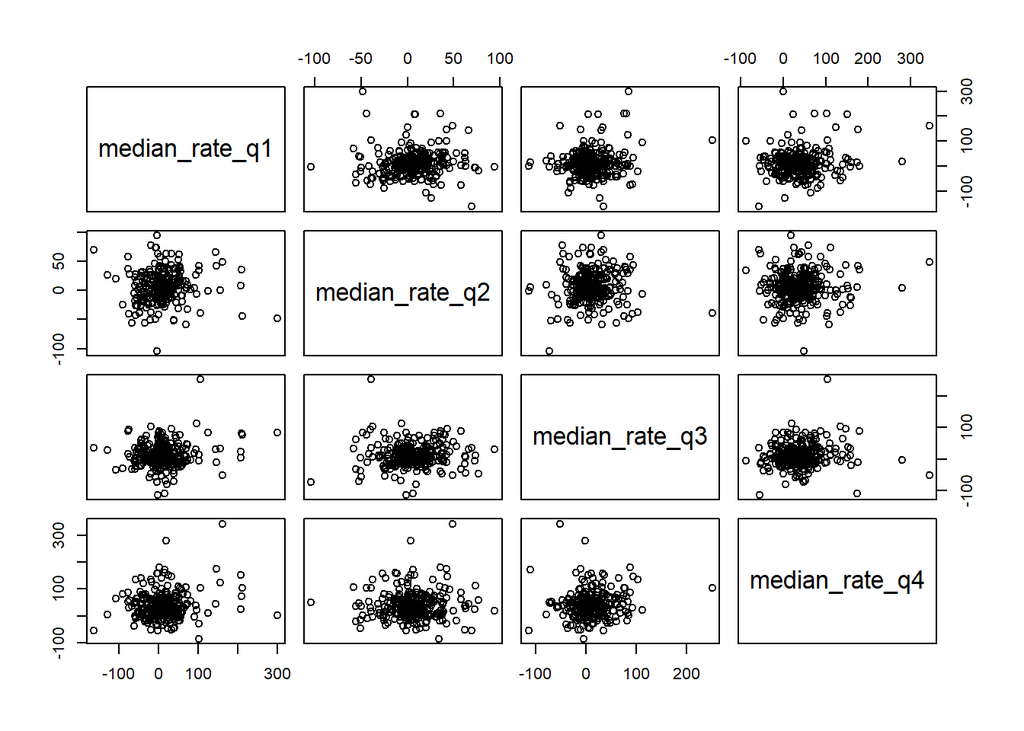

```r
pairs(df[,grepl("median_rate.",names(df))])
```

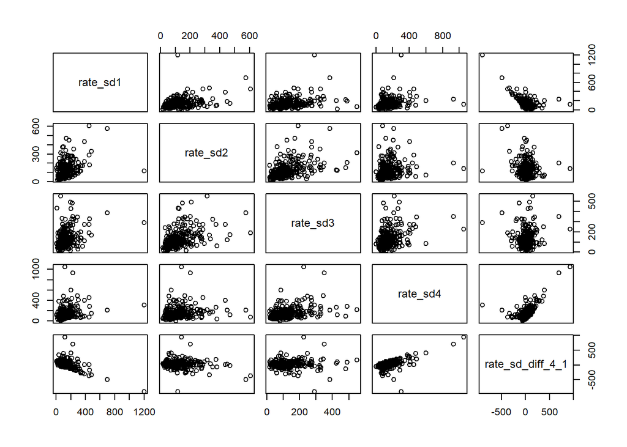

```r
pairs(df[,grepl("rate_sd.",names(df))])
```

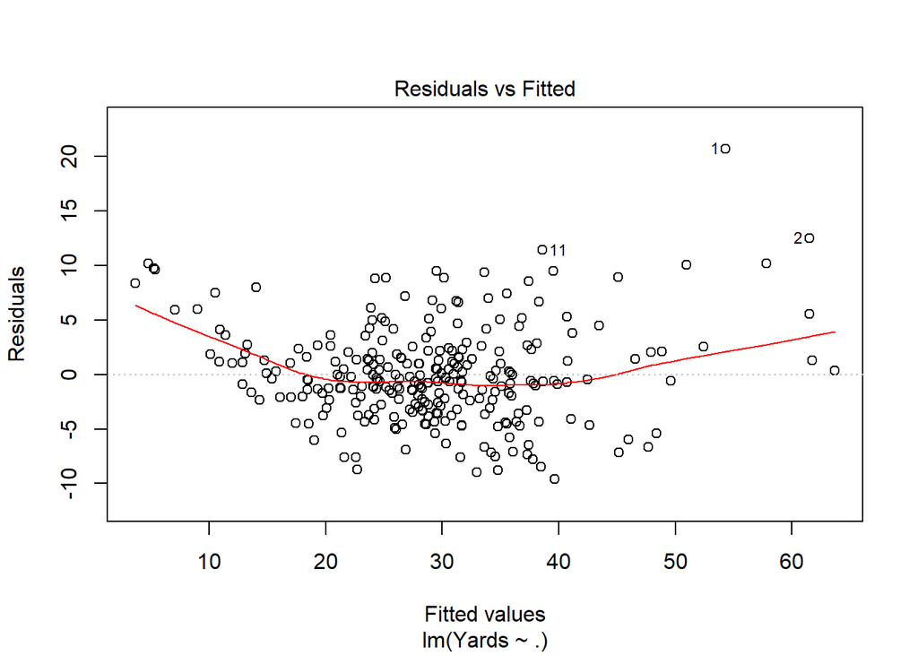

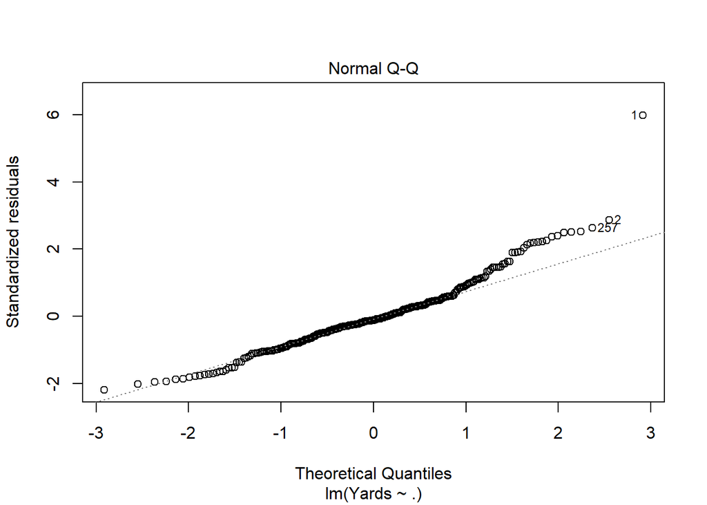

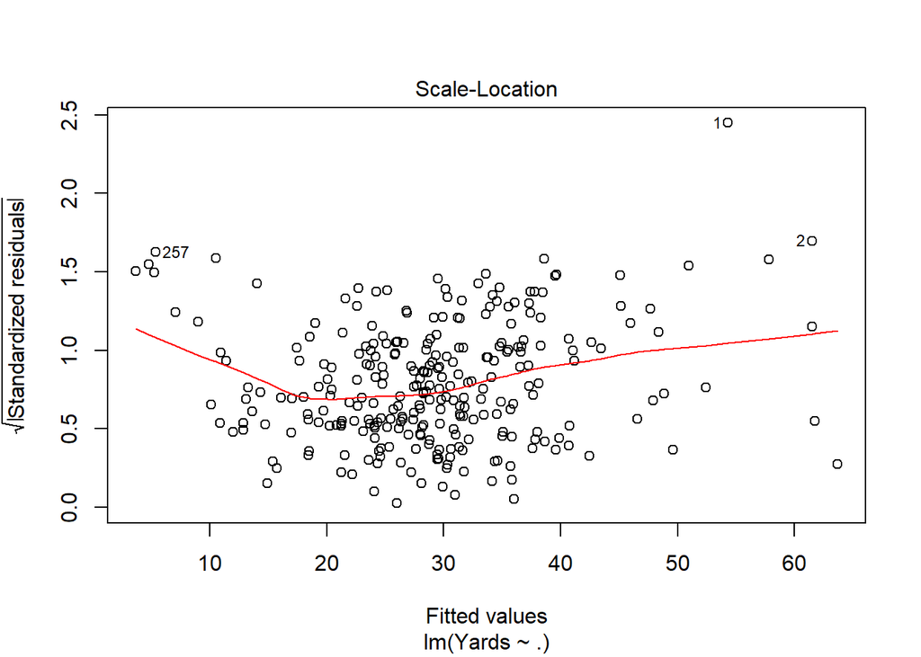

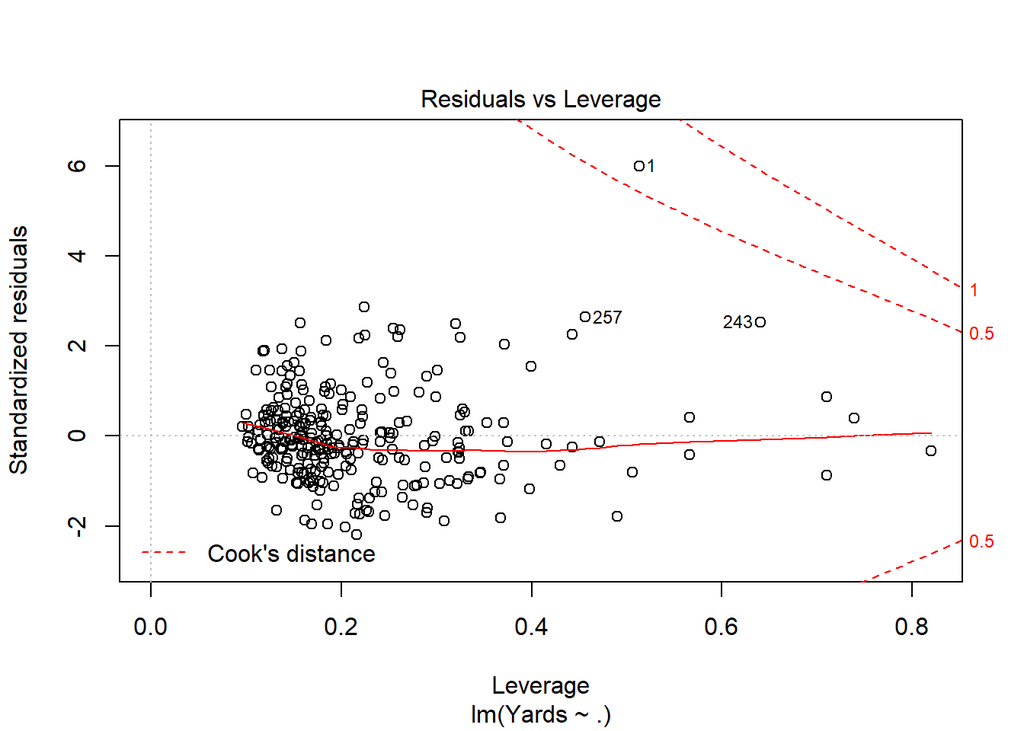

```r
exclude_vars <- names(df) %in% c("Runner" ,"Max", "Min", "Avg" ,"Age", "Team", "Gen", "X", "Gender")
df.filtered <-df[,!exclude_vars]

plot(fit.lm)
```

Test to see if there are any interaction effects between country and the temperature differences.

```r
#Run Model w/ interaction effects
#0- age groups indicate 60-64 age group
#0 - countries indicate Belarus

fit.lm.1 = lm(Yards ~ .+
                Finland:difference+
                Canada:difference+
                Ukraine:difference+
                Switzerland:difference+
                Denmark:difference+
                Belgium:difference+
                Ireland:difference+
                UK:difference+
                Germany:difference+
                France:difference+
                NZ:difference+
                US:difference+
                Japan:difference+
                Spain:difference+
                Australia:difference+
                Mexico:difference+
                India:difference+
                Singapore:difference+
                Russia:difference
                - rate_sd_diff_4_1
                -Age60_64
                -Sweden
                -Russia
                -Finland
                -Canada
                -Ukraine
                -Switzerland
                -Denmark
                -Belgium
                -Ireland
                -UK
                -Germany
                -France
                -NZ
                -US
                -Japan
                -Spain
                -Australia
                -Mexico
                -India
                -Singapore
                -Belarus
                - AvgSeconds #high vif
                ,data = df.filtered)

anova(fit.lm.1)
```

```
## Analysis of Variance Table
##
## Response: Yards
##                         Df Sum Sq Mean Sq  F value    Pr(>F)
## rate_sd1                 1   72.6    72.6   2.9739 0.0860248 .
## rate_sd2                 1 1057.1  1057.1  43.2719 3.427e-10 ***
## rate_sd3                 1  178.3   178.3   7.3001 0.0074327 **
## rate_sd4                 1  273.5   273.5  11.1951 0.0009643 ***
## avg_rate_q1              1  335.5   335.5  13.7342 0.0002665 ***
## avg_rate_q2              1 2203.6  2203.6  90.2056 < 2.2e-16 ***
## avg_rate_q3              1 1398.4  1398.4  57.2449 1.040e-12 ***
## avg_rate_q4              1 4026.7  4026.7 164.8341 < 2.2e-16 ***
## median_rate_q1           1   67.9    67.9   2.7810 0.0968085 .
## median_rate_q2           1  135.8   135.8   5.5577 0.0192773 *
## median_rate_q3           1  193.7   193.7   7.9288 0.0053072 **
## median_rate_q4           1  104.6   104.6   4.2810 0.0397099 *
## sd_q1                    1  732.5   732.5  29.9859 1.184e-07 ***
## sd_q2                    1    0.8     0.8   0.0323 0.8575871
## sd_q3                    1  216.0   216.0   8.8401 0.0032750 **
## sd_q4                    1  477.6   477.6  19.5519 1.539e-05 ***
## avg_sec_q1               1    4.5     4.5   0.1833 0.6689668
## avg_sec_q2               1   48.7    48.7   1.9938 0.1593578
## avg_sec_q3               1    0.0     0.0   0.0018 0.9660868
## avg_sec_q4               1  150.5   150.5   6.1613 0.0138059 *
## median_sec_q1            1    5.0     5.0   0.2037 0.6521831
## median_sec_q2            1  317.2   317.2  12.9848 0.0003883 ***
## median_sec_q3            1  143.4   143.4   5.8706 0.0162049 *
## median_sec_q4            1  329.2   329.2  13.4775 0.0003031 ***
## range_q1                 1 7067.9  7067.9 289.3230 < 2.2e-16 ***
## range_q2                 1 1061.6  1061.6  43.4558 3.168e-10 ***
## range_q3                 1 2115.8  2115.8  86.6098 < 2.2e-16 ***
## range_q4                 1 1266.7  1266.7  51.8505 9.381e-12 ***
## difference               1    3.3     3.3   0.1339 0.7147879
## Age15_19                 1  112.8   112.8   4.6159 0.0327688 *
## Age20_24                 1  156.2   156.2   6.3955 0.0121419 *
## Age25_29                 1   16.0    16.0   0.6564 0.4186991
## Age30_34                 1   13.5    13.5   0.5506 0.4588549
## Age35_39                 1   16.1    16.1   0.6594 0.4176475
## Age40_44                 1    6.9     6.9   0.2841 0.5945439
## Age45_49                 1   36.3    36.3   1.4863 0.2240974
```

[output cut: 11 more lines]

```
## difference:UK            1    0.4     0.4   0.0171 0.8961573
## difference:Germany       1   10.1    10.1   0.4118 0.5217313
## difference:France        1    3.9     3.9   0.1613 0.6883587
## difference:NZ            1   35.0    35.0   1.4321 0.2327093
## difference:US            1  217.8   217.8   8.9141 0.0031501 **
## difference:Japan         1    4.5     4.5   0.1856 0.6669894
## difference:Spain         1   23.1    23.1   0.9475 0.3314247
## difference:Australia     1    0.0     0.0   0.0020 0.9642692
## difference:Mexico        1    2.1     2.1   0.0850 0.7709470
## difference:India         1   31.5    31.5   1.2895 0.2573786
## difference:Singapore     1   69.3    69.3   2.8359 0.0935956 .
## difference:Russia        1    1.7     1.7   0.0702 0.7912570
## Residuals              220 5374.4    24.4
## ---
## Signif. codes:  0 '***' 0.001 '**' 0.01 '*' 0.05 '.' 0.1 ' ' 1
```

```r
summary(fit.lm.1)
```

```
##
## Call:
## lm(formula = Yards ~ . + Finland:difference + Canada:difference +
##     Ukraine:difference + Switzerland:difference + Denmark:difference +
##     Belgium:difference + Ireland:difference + UK:difference +
##     Germany:difference + France:difference + NZ:difference +
##     US:difference + Japan:difference + Spain:difference + Australia:difference +
##     Mexico:difference + India:difference + Singapore:difference +
##     Russia:difference - rate_sd_diff_4_1 - Age60_64 - Sweden -
##     Russia - Finland - Canada - Ukraine - Switzerland - Denmark -
##     Belgium - Ireland - UK - Germany - France - NZ - US - Japan -
##     Spain - Australia - Mexico - India - Singapore - Belarus -
##     AvgSeconds, data = df.filtered)
##
## Residuals:
##     Min      1Q  Median      3Q     Max
## -9.0622 -2.8898 -0.4302  2.1206 20.9092
##
## Coefficients:
##                           Estimate Std. Error t value Pr(>|t|)
## (Intercept)             10.2398309 11.7592543   0.871  0.38482
## rate_sd1                -0.0142823  0.0084148  -1.697  0.09106 .
## rate_sd2                -0.0132729  0.0099748  -1.331  0.18469
## rate_sd3                -0.0164200  0.0089786  -1.829  0.06878 .
## rate_sd4                -0.0123954  0.0060884  -2.036  0.04296 *
## avg_rate_q1             -0.0050247  0.0132310  -0.380  0.70449
## avg_rate_q2             -0.0221520  0.0235618  -0.940  0.34816
## avg_rate_q3              0.0078153  0.0220234   0.355  0.72303
## avg_rate_q4             -0.0327587  0.0125719  -2.606  0.00979 **
## median_rate_q1           0.0080298  0.0094904   0.846  0.39842
## median_rate_q2          -0.0068233  0.0149330  -0.457  0.64817
## median_rate_q3           0.0189708  0.0122019   1.555  0.12145
## median_rate_q4          -0.0106009  0.0090897  -1.166  0.24478
## sd_q1                   -0.1362785  0.0240678  -5.662 4.64e-08 ***
## sd_q2                   -0.0246391  0.0217740  -1.132  0.25904
## sd_q3                   -0.1394032  0.0217196  -6.418 8.35e-10 ***
## sd_q4                   -0.0674943  0.0152732  -4.419 1.56e-05 ***
## avg_sec_q1              -0.0037660  0.0134427  -0.280  0.77963
## avg_sec_q2               0.0027755  0.0144574   0.192  0.84794
## avg_sec_q3               0.0018564  0.0129293   0.144  0.88597
```

[output cut: 31 more lines]

```
## difference:NZ1          -0.2431098  0.3188494  -0.762  0.44660
## difference:US1          -0.0725579  0.4240821  -0.171  0.86431
## difference:Japan1       -0.1907575  0.1828956  -1.043  0.29810
## difference:Spain1       -0.2125767  0.4365820  -0.487  0.62681
## difference:Australia1   -0.1955390  0.3079786  -0.635  0.52615
## difference:Mexico1      -0.2726710  0.4598333  -0.593  0.55380
## difference:India1       -0.0379189  0.2996426  -0.127  0.89941
## difference:Singapore1   -0.2778954  0.1806013  -1.539  0.12531
## difference:Russia1       0.0409724  0.1546124   0.265  0.79126
## ---
## Signif. codes:  0 '***' 0.001 '**' 0.01 '*' 0.05 '.' 0.1 ' ' 1
##
## Residual standard error: 4.943 on 220 degrees of freedom
## Multiple R-squared:   0.83,  Adjusted R-squared:  0.7844
## F-statistic:  18.2 on 59 and 220 DF,  p-value: < 2.2e-16
```

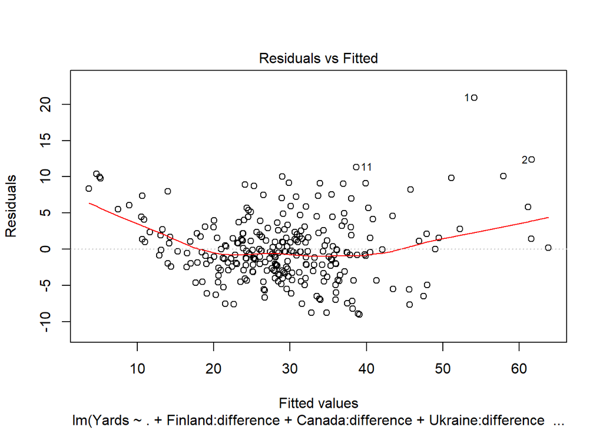

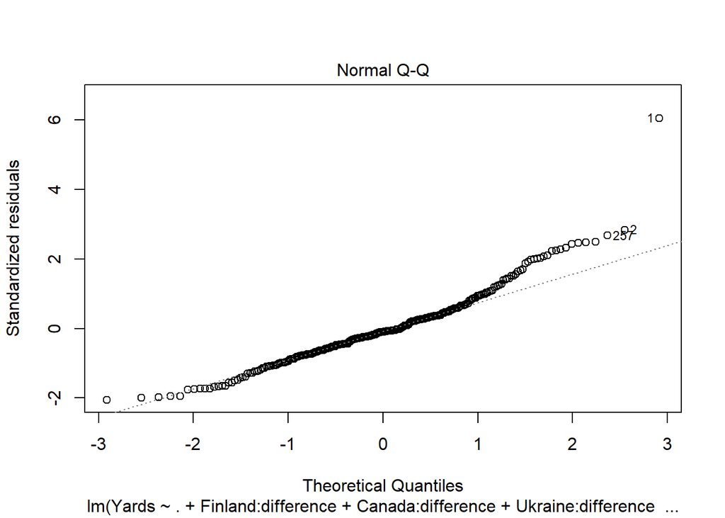

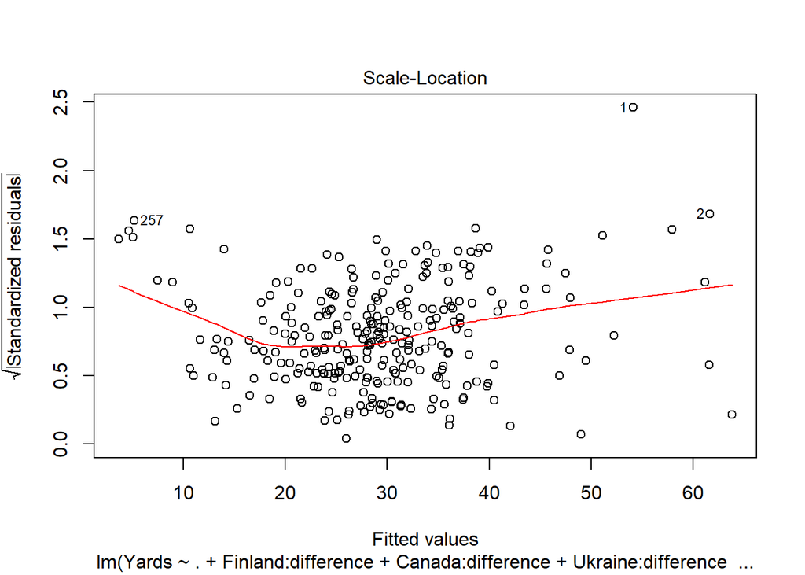

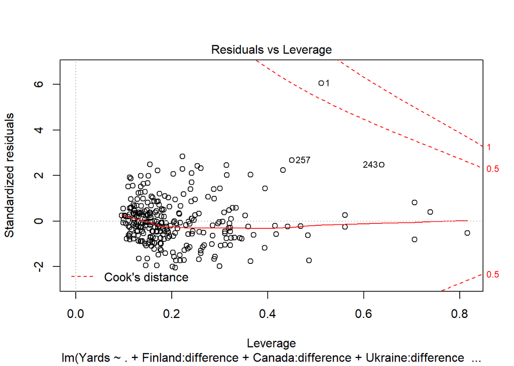

```r
plot(fit.lm.1)
```

```r
library(car)
vif(fit.lm.1)
```

```
##               rate_sd1               rate_sd2               rate_sd3
##               9.812715               8.923713               6.899134
##               rate_sd4            avg_rate_q1            avg_rate_q2
##               5.738952               4.926071               3.852296
##            avg_rate_q3            avg_rate_q4         median_rate_q1
##               3.977949               4.956446               2.712191
##         median_rate_q2         median_rate_q3         median_rate_q4
##               1.706671               2.283946               2.368986
##                  sd_q1                  sd_q2                  sd_q3
##              44.177944              23.726091              20.344477
##                  sd_q4             avg_sec_q1             avg_sec_q2
##              24.497619              87.326784              75.042745
##             avg_sec_q3             avg_sec_q4          median_sec_q1
##              58.951618              71.839227              66.991026
##          median_sec_q2          median_sec_q3          median_sec_q4
##              51.828682              39.878950              45.030081
##               range_q1               range_q2               range_q3
##              42.378412              25.603148              21.772330
##               range_q4             difference               Age15_19
##              28.613107             297.491001               1.954818
##               Age20_24               Age25_29               Age30_34
##               2.461091              10.807177              16.809477
##               Age35_39               Age40_44               Age45_49
##              27.549518              30.457806              29.646254
##               Age50_54               Age55_59             MaxSeconds
##              14.862932               5.600322              12.772433
##             MinSeconds     difference:Finland      difference:Canada
##              11.268487              31.877741               3.267484
##     difference:Ukraine difference:Switzerland     difference:Denmark
##               3.005924               8.794704              24.825301
##     difference:Belgium     difference:Ireland          difference:UK
##               2.564573               6.598096               6.179053
##     difference:Germany      difference:France          difference:NZ
##              10.134823               4.225515              31.253616
##          difference:US       difference:Japan       difference:Spain
##              93.452451               3.380231             120.623790
##   difference:Australia      difference:Mexico       difference:India
##              26.678395             128.842185              12.806048
##   difference:Singapore      difference:Russia
##               4.237135               2.199485
```

Huge VIF values were noticed, tons of multicollinearity

Need to check Boxplots point 1 (winner) is suspected of being an outlier, we will remove observation for further analysis

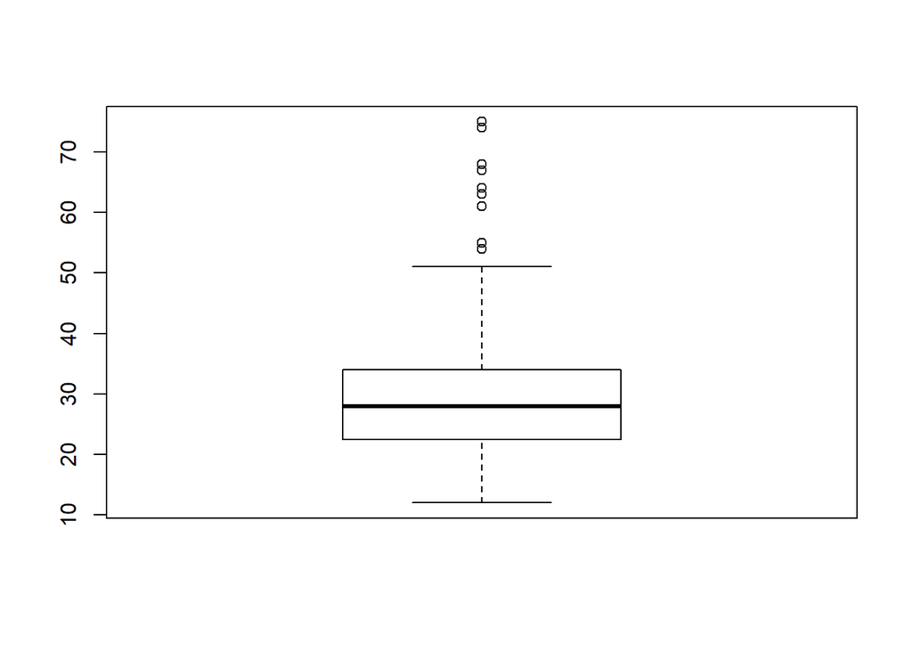

```r
boxplot(df$Yards)
```

```r
mean(df$Yards)
```

```
## [1] 29.07143
```

```r
median(df$Yards)
```

```
## [1] 28
```

```r
#remove points 1 almost 3x as large
df.filtered = df.filtered[-c(1),]
fit.lm.2 = lm(Yards ~ .+
                Finland:difference+
                Canada:difference+
                Ukraine:difference+
                Switzerland:difference+
                Denmark:difference+
                Belgium:difference+
                Ireland:difference+
                UK:difference+
                Germany:difference+
                France:difference+
                NZ:difference+
                US:difference+
                Japan:difference+
                Spain:difference+
                Australia:difference+
                Mexico:difference+
                India:difference+
                Singapore:difference+
                Russia:difference
                - rate_sd_diff_4_1
                -Age60_64
                -Sweden
                -Russia
                -Finland
                -Canada
                -Ukraine
                -Switzerland
                -Denmark
                -Belgium
                -Ireland
                -UK
                -Germany
                -France
                -NZ
                -US
                -Japan
                -Spain
                -Australia
                -Mexico
                -India
                -Singapore
                -Belarus
                - AvgSeconds #high vif
                ,data = df.filtered)

summary(fit.lm.2)
```

```
##
## Call:
## lm(formula = Yards ~ . + Finland:difference + Canada:difference +
##     Ukraine:difference + Switzerland:difference + Denmark:difference +
##     Belgium:difference + Ireland:difference + UK:difference +
##     Germany:difference + France:difference + NZ:difference +
##     US:difference + Japan:difference + Spain:difference + Australia:difference +
##     Mexico:difference + India:difference + Singapore:difference +
##     Russia:difference - rate_sd_diff_4_1 - Age60_64 - Sweden -
##     Russia - Finland - Canada - Ukraine - Switzerland - Denmark -
##     Belgium - Ireland - UK - Germany - France - NZ - US - Japan -
##     Spain - Australia - Mexico - India - Singapore - Belarus -
##     AvgSeconds, data = df.filtered)
##
## Residuals:
##     Min      1Q  Median      3Q     Max
## -9.9468 -2.5853 -0.3222  1.9892 13.9906
##
## Coefficients:
##                           Estimate Std. Error t value Pr(>|t|)
## (Intercept)             19.8227244 10.8570121   1.826 0.069242 .
## rate_sd1                -0.0190399  0.0077332  -2.462 0.014585 *
## rate_sd2                -0.0035882  0.0092438  -0.388 0.698265
## rate_sd3                -0.0187585  0.0082232  -2.281 0.023499 *
## rate_sd4                -0.0022691  0.0057775  -0.393 0.694893
## avg_rate_q1             -0.0131892  0.0121694  -1.084 0.279646
## avg_rate_q2             -0.0093754  0.0216458  -0.433 0.665348
## avg_rate_q3             -0.0251868  0.0207601  -1.213 0.226348
## avg_rate_q4             -0.0324793  0.0115036  -2.823 0.005190 **
## median_rate_q1           0.0136300  0.0087251   1.562 0.119693
## median_rate_q2          -0.0115400  0.0136826  -0.843 0.399920
## median_rate_q3           0.0252235  0.0112049   2.251 0.025371 *
## median_rate_q4          -0.0118473  0.0083194  -1.424 0.155852
## sd_q1                   -0.1723316  0.0226868  -7.596 8.77e-13 ***
## sd_q2                   -0.0227122  0.0199257  -1.140 0.255597
## sd_q3                   -0.1141687  0.0202366  -5.642 5.17e-08 ***
## sd_q4                   -0.0784345  0.0140728  -5.573 7.30e-08 ***
## avg_sec_q1              -0.0318202  0.0130109  -2.446 0.015248 *
## avg_sec_q2               0.0004265  0.0132335   0.032 0.974321
## avg_sec_q3              -0.0040854  0.0118646  -0.344 0.730925
```

[output cut: 31 more lines]

```
## difference:NZ1          -0.2214114  0.2917716  -0.759 0.448757
## difference:US1          -0.0116764  0.3881522  -0.030 0.976029
## difference:Japan1       -0.1410840  0.1675213  -0.842 0.400603
## difference:Spain1       -0.1546977  0.3995766  -0.387 0.699018
## difference:Australia1   -0.1399047  0.2819316  -0.496 0.620226
## difference:Mexico1      -0.1908364  0.4209379  -0.453 0.650738
## difference:India1        0.0652662  0.2746219   0.238 0.812368
## difference:Singapore1   -0.2167108  0.1655122  -1.309 0.191793
## difference:Russia1       0.1156776  0.1419232   0.815 0.415917
## ---
## Signif. codes:  0 '***' 0.001 '**' 0.01 '*' 0.05 '.' 0.1 ' ' 1
##
## Residual standard error: 4.523 on 219 degrees of freedom
## Multiple R-squared:  0.8481, Adjusted R-squared:  0.8072
## F-statistic: 20.73 on 59 and 219 DF,  p-value: < 2.2e-16
```

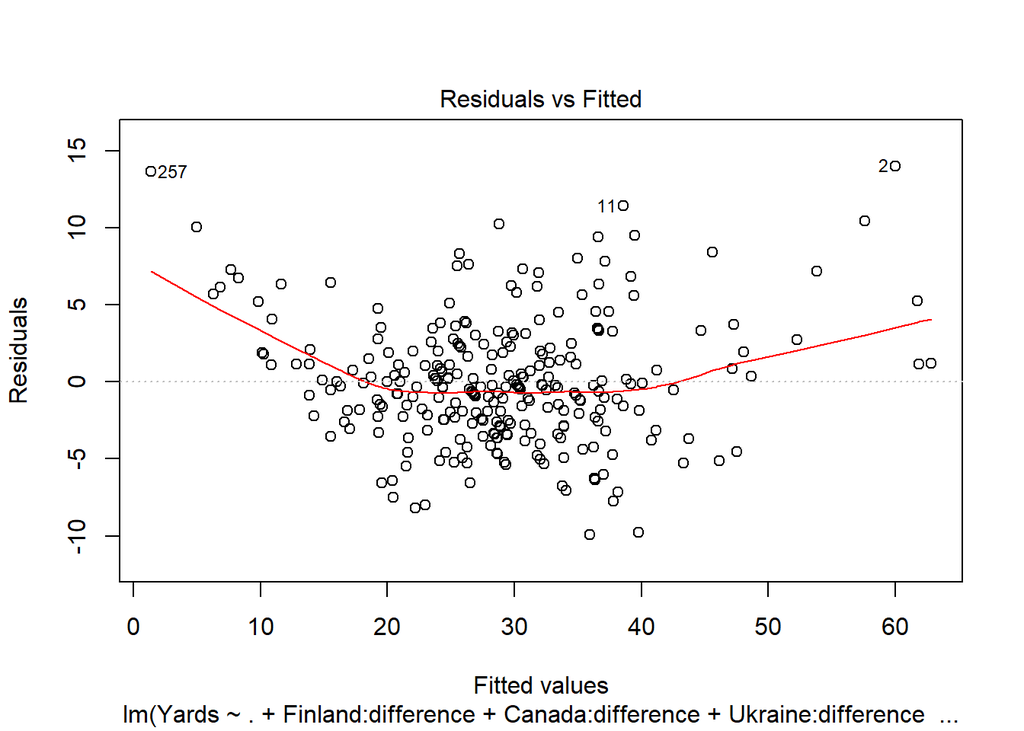

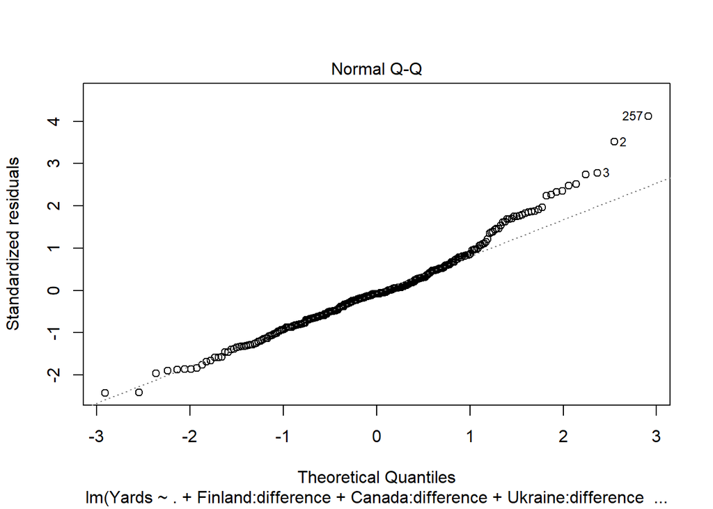

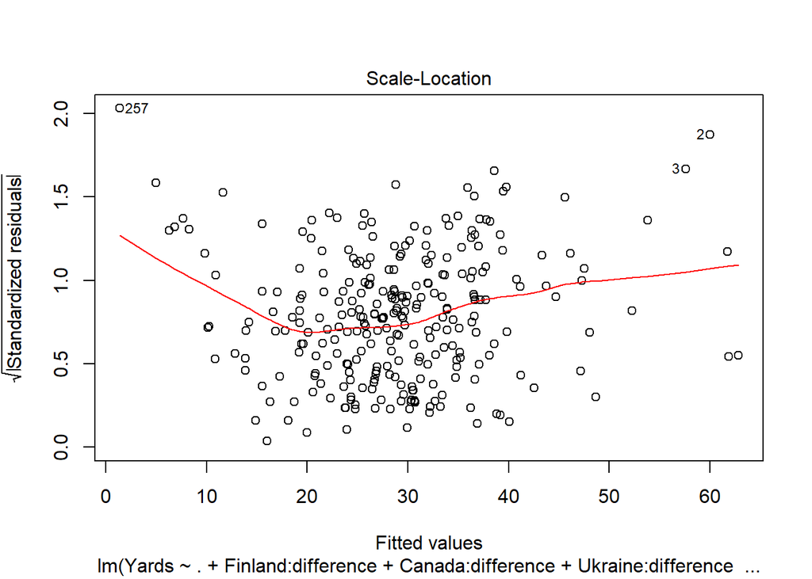

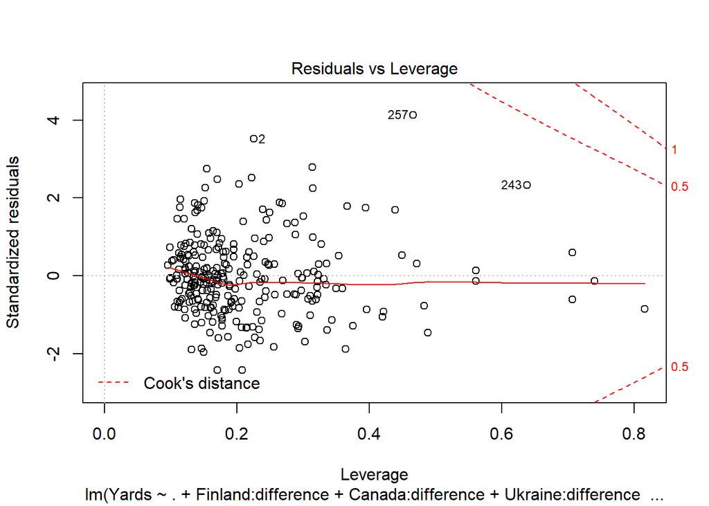

```r
plot(fit.lm.2)
```

```r
a =boxCox(fit.lm.2,data = df.filtered)

library(olsrr)
```

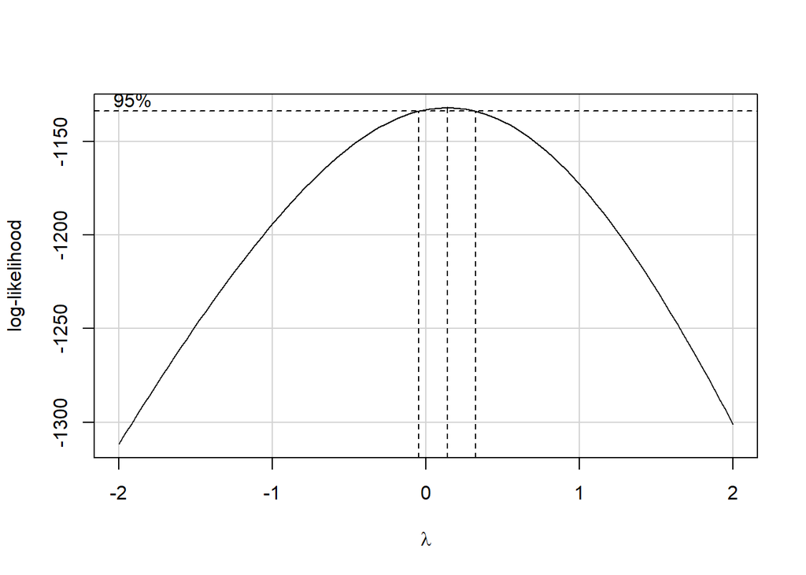

```r
outlierTest(fit.lm.2, cutoff = .05)
```

```
##     rstudent unadjusted p-value Bonferroni p
## 257 4.287262         2.7165e-05    0.0075519
```

It looks like Age does not have any impact for the analysis. Run Partial F-Test to validate.

```r
#Removed Age
fit.lm.3 = lm(Yards ~ .+
                Finland:difference+
                Canada:difference+
                Ukraine:difference+
                Switzerland:difference+
                Denmark:difference+
                Belgium:difference+
                Ireland:difference+
                UK:difference+
                Germany:difference+
                France:difference+
                NZ:difference+
                US:difference+
                Japan:difference+
                Spain:difference+
                Australia:difference+
                Mexico:difference+
                India:difference+
                Singapore:difference+
                Russia:difference
                - rate_sd_diff_4_1
                - Age55_59
              - Age50_54
              - Age45_49
              - Age40_44
              - Age35_39
              - Age30_34
              - Age25_29
              - Age20_24
              - Age15_19
                -Age60_64
                -Sweden
                -Russia
                -Finland
                -Canada
                -Ukraine
                -Switzerland
                -Denmark
                -Belgium
                -Ireland
                -UK
                -Germany
                -France
                -NZ
                -US
                -Japan
                -Spain
                -Australia
                -Mexico
                -India
                -Singapore
                -Belarus
                - AvgSeconds #high vif
                ,data = df.filtered)
anova(fit.lm.2, fit.lm.3)
```

```
## Analysis of Variance Table
##
## Model 1: Yards ~ rate_sd1 + rate_sd2 + rate_sd3 + rate_sd4 + avg_rate_q1 +
##     avg_rate_q2 + avg_rate_q3 + avg_rate_q4 + median_rate_q1 +
##     median_rate_q2 + median_rate_q3 + median_rate_q4 + sd_q1 +
##     sd_q2 + sd_q3 + sd_q4 + avg_sec_q1 + avg_sec_q2 + avg_sec_q3 +
##     avg_sec_q4 + median_sec_q1 + median_sec_q2 + median_sec_q3 +
##     median_sec_q4 + range_q1 + range_q2 + range_q3 + range_q4 +
##     rate_sd_diff_4_1 + difference + Australia + Belarus + Belgium +
##     Canada + Denmark + Finland + France + Germany + India + Ireland +
##     Japan + Mexico + NZ + Russia + Singapore + Spain + Sweden +
##     Switzerland + Ukraine + UK + US + Age15_19 + Age20_24 + Age25_29 +
##     Age30_34 + Age35_39 + Age40_44 + Age45_49 + Age50_54 + Age55_59 +
##     Age60_64 + AvgSeconds + MaxSeconds + MinSeconds + Finland:difference +
##     Canada:difference + Ukraine:difference + Switzerland:difference +
##     Denmark:difference + Belgium:difference + Ireland:difference +
##     UK:difference + Germany:difference + France:difference +
##     NZ:difference + US:difference + Japan:difference + Spain:difference +
##     Australia:difference + Mexico:difference + India:difference +
##     Singapore:difference + Russia:difference - rate_sd_diff_4_1 -
##     Age60_64 - Sweden - Russia - Finland - Canada - Ukraine -
##     Switzerland - Denmark - Belgium - Ireland - UK - Germany -
##     France - NZ - US - Japan - Spain - Australia - Mexico - India -
##     Singapore - Belarus - AvgSeconds
## Model 2: Yards ~ rate_sd1 + rate_sd2 + rate_sd3 + rate_sd4 + avg_rate_q1 +
##     avg_rate_q2 + avg_rate_q3 + avg_rate_q4 + median_rate_q1 +
##     median_rate_q2 + median_rate_q3 + median_rate_q4 + sd_q1 +
##     sd_q2 + sd_q3 + sd_q4 + avg_sec_q1 + avg_sec_q2 + avg_sec_q3 +
##     avg_sec_q4 + median_sec_q1 + median_sec_q2 + median_sec_q3 +
##     median_sec_q4 + range_q1 + range_q2 + range_q3 + range_q4 +
##     rate_sd_diff_4_1 + difference + Australia + Belarus + Belgium +
##     Canada + Denmark + Finland + France + Germany + India + Ireland +
##     Japan + Mexico + NZ + Russia + Singapore + Spain + Sweden +
##     Switzerland + Ukraine + UK + US + Age15_19 + Age20_24 + Age25_29 +
##     Age30_34 + Age35_39 + Age40_44 + Age45_49 + Age50_54 + Age55_59 +
##     Age60_64 + AvgSeconds + MaxSeconds + MinSeconds + Finland:difference +
##     Canada:difference + Ukraine:difference + Switzerland:difference +
##     Denmark:difference + Belgium:difference + Ireland:difference +
##     UK:difference + Germany:difference + France:difference +
##     NZ:difference + US:difference + Japan:difference + Spain:difference +
##     Australia:difference + Mexico:difference + India:difference +
##     Singapore:difference + Russia:difference - rate_sd_diff_4_1 -
##     Age55_59 - Age50_54 - Age45_49 - Age40_44 - Age35_39 - Age30_34 -
##     Age25_29 - Age20_24 - Age15_19 - Age60_64 - Sweden - Russia -
##     Finland - Canada - Ukraine - Switzerland - Denmark - Belgium -
##     Ireland - UK - Germany - France - NZ - US - Japan - Spain -
##     Australia - Mexico - India - Singapore - Belarus - AvgSeconds
##   Res.Df    RSS Df Sum of Sq      F Pr(>F)
## 1    219 4479.3
## 2    228 4718.7 -9   -239.35 1.3003  0.238
```

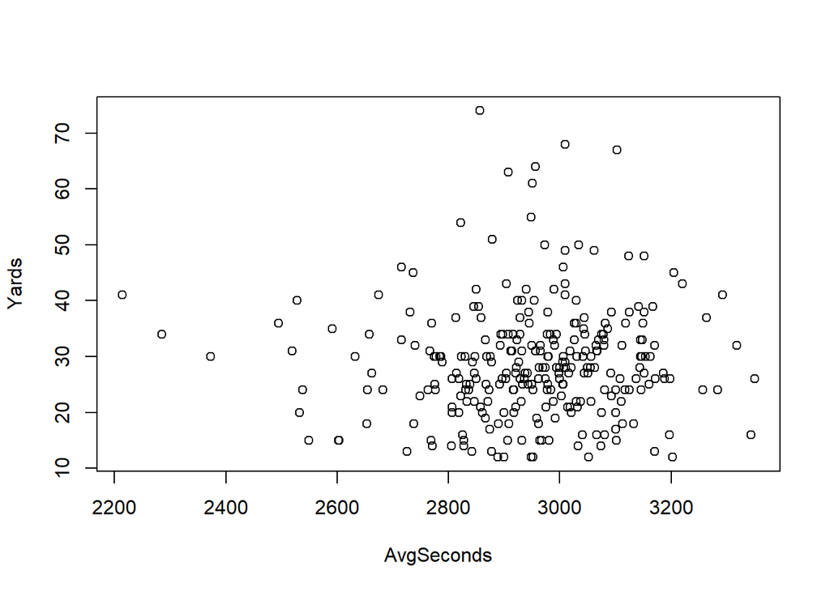

```r
plot(Yards~AvgSeconds, data = df.filtered)
```

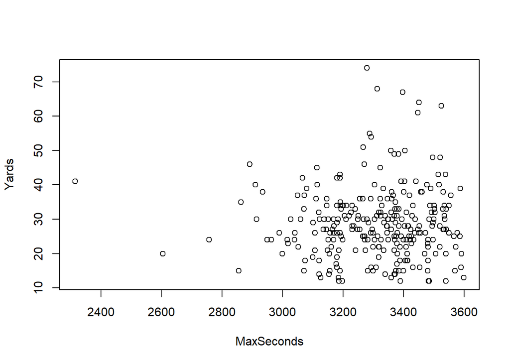

```r
plot(Yards~MaxSeconds, data = df.filtered)
```

Remove interaction effects between temperature and country

```r
fit.lm.4 = lm(Yards ~ .
                - rate_sd_diff_4_1
                -Age60_64
                -Sweden
                -Russia
                -Finland
                -Canada
                -Ukraine
                -Switzerland
                -Denmark
                -Belgium
                -Ireland
                -UK
                -Germany
                -France
                -NZ
                -US
                -Japan
                -Spain
                -Australia
                -Mexico
                -India
                -Singapore
                -Belarus
                - AvgSeconds #high vif
                ,data = df.filtered)
anova(fit.lm.4, fit.lm.2)
```

```
## Analysis of Variance Table
##
## Model 1: Yards ~ (rate_sd1 + rate_sd2 + rate_sd3 + rate_sd4 + avg_rate_q1 +
##     avg_rate_q2 + avg_rate_q3 + avg_rate_q4 + median_rate_q1 +
##     median_rate_q2 + median_rate_q3 + median_rate_q4 + sd_q1 +
##     sd_q2 + sd_q3 + sd_q4 + avg_sec_q1 + avg_sec_q2 + avg_sec_q3 +
##     avg_sec_q4 + median_sec_q1 + median_sec_q2 + median_sec_q3 +
##     median_sec_q4 + range_q1 + range_q2 + range_q3 + range_q4 +
##     rate_sd_diff_4_1 + difference + Australia + Belarus + Belgium +
##     Canada + Denmark + Finland + France + Germany + India + Ireland +
##     Japan + Mexico + NZ + Russia + Singapore + Spain + Sweden +
##     Switzerland + Ukraine + UK + US + Age15_19 + Age20_24 + Age25_29 +
##     Age30_34 + Age35_39 + Age40_44 + Age45_49 + Age50_54 + Age55_59 +
##     Age60_64 + AvgSeconds + MaxSeconds + MinSeconds) - rate_sd_diff_4_1 -
##     Age60_64 - Sweden - Russia - Finland - Canada - Ukraine -
##     Switzerland - Denmark - Belgium - Ireland - UK - Germany -
##     France - NZ - US - Japan - Spain - Australia - Mexico - India -
##     Singapore - Belarus - AvgSeconds
## Model 2: Yards ~ rate_sd1 + rate_sd2 + rate_sd3 + rate_sd4 + avg_rate_q1 +
##     avg_rate_q2 + avg_rate_q3 + avg_rate_q4 + median_rate_q1 +
##     median_rate_q2 + median_rate_q3 + median_rate_q4 + sd_q1 +
##     sd_q2 + sd_q3 + sd_q4 + avg_sec_q1 + avg_sec_q2 + avg_sec_q3 +
##     avg_sec_q4 + median_sec_q1 + median_sec_q2 + median_sec_q3 +
##     median_sec_q4 + range_q1 + range_q2 + range_q3 + range_q4 +
##     rate_sd_diff_4_1 + difference + Australia + Belarus + Belgium +
##     Canada + Denmark + Finland + France + Germany + India + Ireland +
##     Japan + Mexico + NZ + Russia + Singapore + Spain + Sweden +
##     Switzerland + Ukraine + UK + US + Age15_19 + Age20_24 + Age25_29 +
##     Age30_34 + Age35_39 + Age40_44 + Age45_49 + Age50_54 + Age55_59 +
##     Age60_64 + AvgSeconds + MaxSeconds + MinSeconds + Finland:difference +
##     Canada:difference + Ukraine:difference + Switzerland:difference +
##     Denmark:difference + Belgium:difference + Ireland:difference +
##     UK:difference + Germany:difference + France:difference +
##     NZ:difference + US:difference + Japan:difference + Spain:difference +
##     Australia:difference + Mexico:difference + India:difference +
##     Singapore:difference + Russia:difference - rate_sd_diff_4_1 -
##     Age60_64 - Sweden - Russia - Finland - Canada - Ukraine -
##     Switzerland - Denmark - Belgium - Ireland - UK - Germany -
##     France - NZ - US - Japan - Spain - Australia - Mexico - India -
##     Singapore - Belarus - AvgSeconds
##   Res.Df    RSS Df Sum of Sq      F    Pr(>F)
## 1    238 5497.6
## 2    219 4479.3 19    1018.3 2.6203 0.0004128 ***
## ---
## Signif. codes:  0 '***' 0.001 '**' 0.01 '*' 0.05 '.' 0.1 ' ' 1
```

```r
#Get rid of ages but keep interactions
```

Base on partial F-test above lets put interactions back but remove ages.

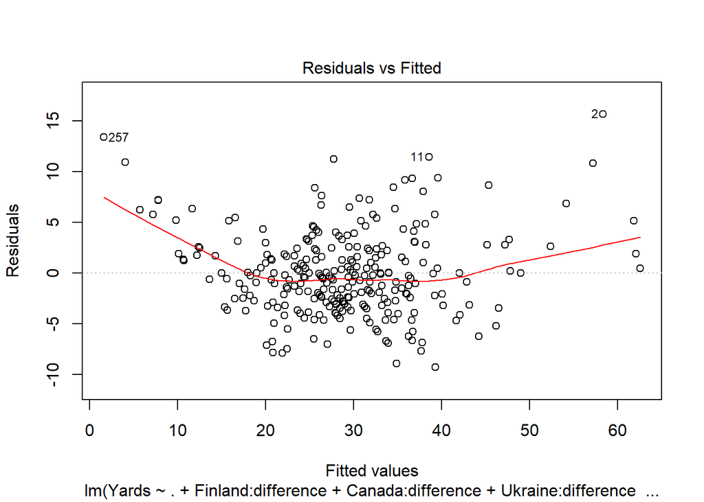

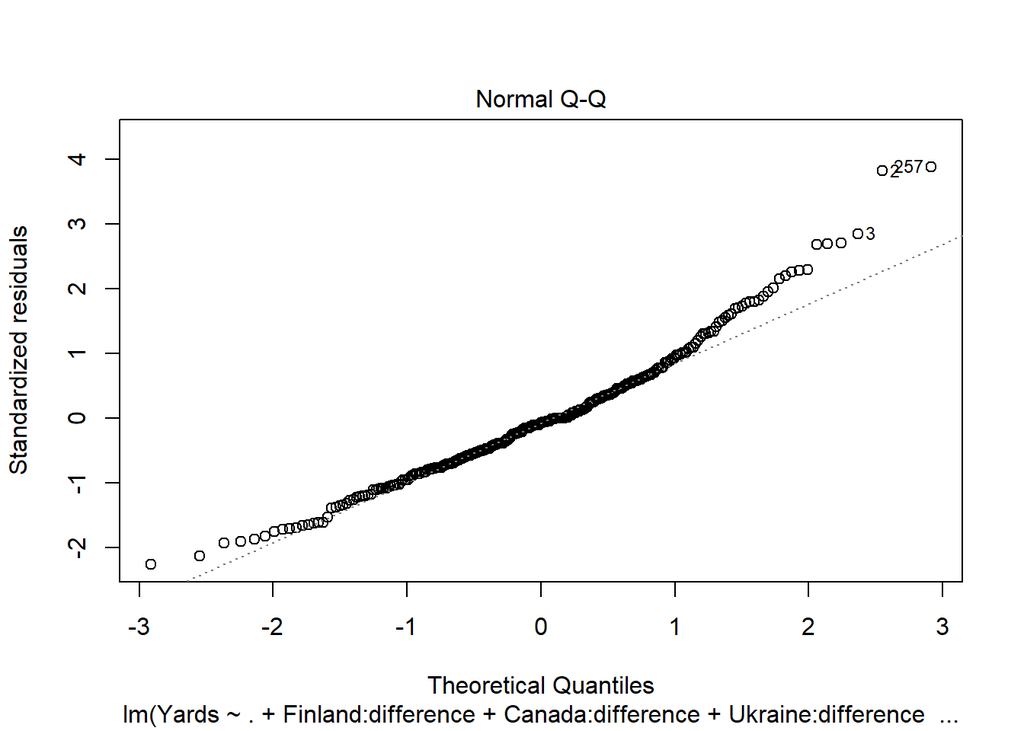

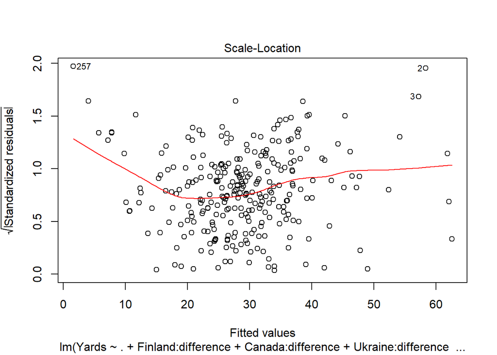

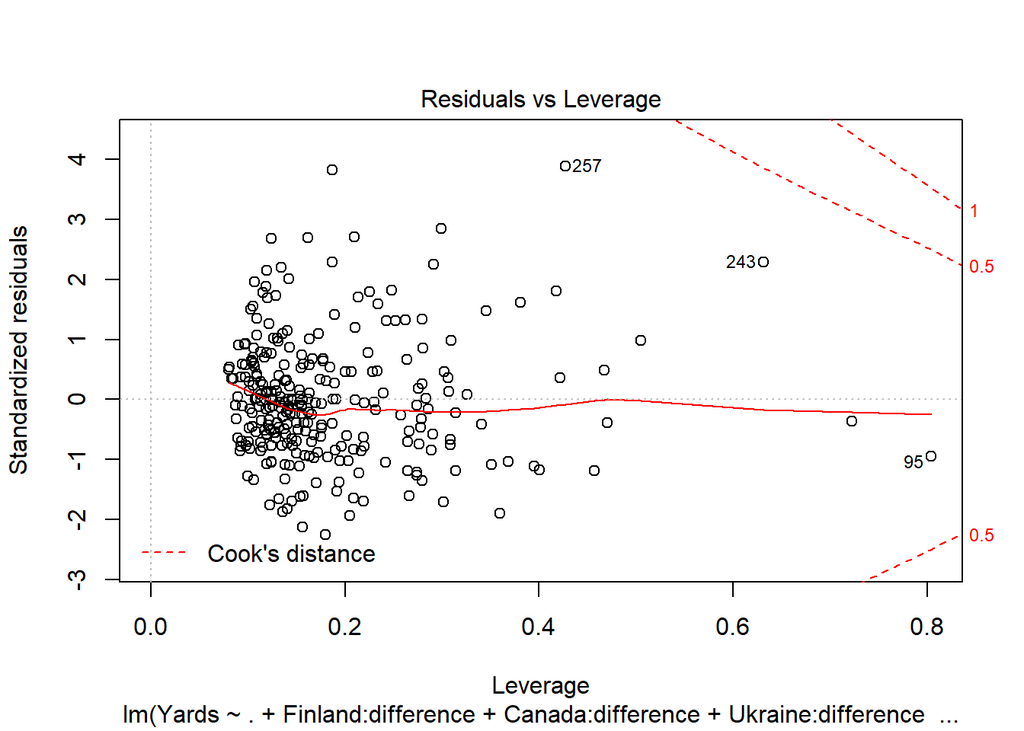

```r
fit.lm.5 = lm(Yards ~ .+
                Finland:difference+
                Canada:difference+
                Ukraine:difference+
                Switzerland:difference+
                Denmark:difference+
                Belgium:difference+
                Ireland:difference+
                UK:difference+
                Germany:difference+
                France:difference+
                NZ:difference+
                US:difference+
                Japan:difference+
                Spain:difference+
                Australia:difference+
                Mexico:difference+
                India:difference+
                Singapore:difference+
                Russia:difference
- rate_sd_diff_4_1
- Age55_59
- Age50_54
- Age45_49
- Age40_44
- Age35_39
- Age30_34
- Age25_29
- Age20_24
- Age15_19
-Age60_64
-Sweden
-Russia
-Finland
-Canada
-Ukraine
-Switzerland
-Denmark
-Belgium
-Ireland
-UK
-Germany
-France
-NZ
-US
-Japan
-Spain
-Australia
-Mexico
-India
-Singapore
-Belarus
- AvgSeconds #high vif
                ,data = df.filtered)

plot(fit.lm.5)
```

```r
summary(fit.lm.5)
```

```
##
## Call:
## lm(formula = Yards ~ . + Finland:difference + Canada:difference +
##     Ukraine:difference + Switzerland:difference + Denmark:difference +
##     Belgium:difference + Ireland:difference + UK:difference +
##     Germany:difference + France:difference + NZ:difference +
##     US:difference + Japan:difference + Spain:difference + Australia:difference +
##     Mexico:difference + India:difference + Singapore:difference +
##     Russia:difference - rate_sd_diff_4_1 - Age55_59 - Age50_54 -
##     Age45_49 - Age40_44 - Age35_39 - Age30_34 - Age25_29 - Age20_24 -
##     Age15_19 - Age60_64 - Sweden - Russia - Finland - Canada -
##     Ukraine - Switzerland - Denmark - Belgium - Ireland - UK -
##     Germany - France - NZ - US - Japan - Spain - Australia -
##     Mexico - India - Singapore - Belarus - AvgSeconds, data = df.filtered)
##
## Residuals:
##     Min      1Q  Median      3Q     Max
## -9.3048 -2.8232 -0.2912  2.3558 15.6522
##
## Coefficients:
##                           Estimate Std. Error t value Pr(>|t|)
## (Intercept)             23.0077410  9.8585946   2.334 0.020478 *
## rate_sd1                -0.0176028  0.0075314  -2.337 0.020293 *
## rate_sd2                -0.0022558  0.0090778  -0.248 0.803975
## rate_sd3                -0.0182934  0.0079893  -2.290 0.022950 *
## rate_sd4                -0.0007923  0.0055118  -0.144 0.885829
## avg_rate_q1             -0.0130396  0.0120950  -1.078 0.282130
## avg_rate_q2             -0.0037698  0.0215645  -0.175 0.861381
## avg_rate_q3             -0.0228376  0.0203957  -1.120 0.264007
## avg_rate_q4             -0.0389674  0.0112895  -3.452 0.000664 ***
## median_rate_q1           0.0139024  0.0087412   1.590 0.113119
## median_rate_q2          -0.0120616  0.0136656  -0.883 0.378370
## median_rate_q3           0.0225981  0.0111352   2.029 0.043577 *
## median_rate_q4          -0.0077091  0.0077710  -0.992 0.322228
## sd_q1                   -0.1753764  0.0225078  -7.792 2.32e-13 ***
## sd_q2                   -0.0308955  0.0195018  -1.584 0.114526
## sd_q3                   -0.1083367  0.0198563  -5.456 1.27e-07 ***
## sd_q4                   -0.0777380  0.0140328  -5.540 8.32e-08 ***
## avg_sec_q1              -0.0332629  0.0128755  -2.583 0.010407 *
## avg_sec_q2               0.0031646  0.0131200   0.241 0.809612
```

[output cut: 23 more lines]

```
## difference:NZ1          -0.2587256  0.2882909  -0.897 0.370427
## difference:US1          -0.0895231  0.3825090  -0.234 0.815162
## difference:Japan1       -0.1504357  0.1636460  -0.919 0.358923
## difference:Spain1       -0.2230481  0.3940980  -0.566 0.571970
## difference:Australia1   -0.1793697  0.2792281  -0.642 0.521274
## difference:Mexico1      -0.2715131  0.4148615  -0.654 0.513471
## difference:India1        0.0947706  0.2699241   0.351 0.725837
## difference:Singapore1   -0.2437729  0.1623960  -1.501 0.134713
## difference:Russia1       0.0915803  0.1394716   0.657 0.512085
## ---
## Signif. codes:  0 '***' 0.001 '**' 0.01 '*' 0.05 '.' 0.1 ' ' 1
##
## Residual standard error: 4.549 on 228 degrees of freedom
## Multiple R-squared:   0.84,  Adjusted R-squared:  0.8049
## F-statistic: 23.94 on 50 and 228 DF,  p-value: < 2.2e-16
```

```r
vif(fit.lm.5)
```

```
##               rate_sd1               rate_sd2               rate_sd3
##               9.167446               8.714391               6.432316
##               rate_sd4            avg_rate_q1            avg_rate_q2
##               5.542541               4.855298               3.808935
##            avg_rate_q3            avg_rate_q4         median_rate_q1
##               4.026296               4.701290               2.715199
##         median_rate_q2         median_rate_q3         median_rate_q4
##               1.687012               2.243497               2.040355
##                  sd_q1                  sd_q2                  sd_q3
##              44.819142              22.294370              20.036860
##                  sd_q4             avg_sec_q1             avg_sec_q2
##              24.404190              94.311429              72.937731
##             avg_sec_q3             avg_sec_q4          median_sec_q1
##              56.709621              70.733326              79.860406
##          median_sec_q2          median_sec_q3          median_sec_q4
##              50.948761              38.032501              42.864351
##               range_q1               range_q2               range_q3
##              41.420942              24.741829              21.908448
##               range_q4             difference             MaxSeconds
##              28.151785             286.154673              12.684373
##             MinSeconds     difference:Finland      difference:Canada
##              10.914181              30.551125               3.061669
##     difference:Ukraine difference:Switzerland     difference:Denmark
##               2.902135               8.529907              23.645252
##     difference:Belgium     difference:Ireland          difference:UK
##               2.280755               6.349975               5.870699
##     difference:Germany      difference:France          difference:NZ
##               9.696932               3.993159              30.152639
##          difference:US       difference:Japan       difference:Spain
##              89.726554               3.193860             115.996342
##   difference:Australia      difference:Mexico       difference:India
##              25.880430             123.770328              12.264847
##   difference:Singapore      difference:Russia
##               4.043228               2.112247
```

Lets remove ages to make it easier to have the model statements.

```r
exclude_vars <- names(df.filtered) %in% c("rate_sd_diff_4_1",
"Age55_59",
"Age50_54",
"Age45_49",
"Age40_44",
"Age35_39",
"Age30_34",
"Age25_29",
"Age20_24",
"Age15_19",
"Age60_64",
"AvgSeconds"
)


df.filtered.2 <-df.filtered[,!exclude_vars]
```

Explore the relationship Yards has with the rest of the variables. based on the Residuals vs Fitted plot below we should try a Log transformation to stablize the curve.

```r
fit.lm.6 = lm(Yards ~ .+
                Finland:difference+
                Canada:difference+
                Ukraine:difference+
                Switzerland:difference+
                Denmark:difference+
                Belgium:difference+
                Ireland:difference+
                UK:difference+
                Germany:difference+
                France:difference+
                NZ:difference+
                US:difference+
                Japan:difference+
                Spain:difference+
                Australia:difference+
                Mexico:difference+
                India:difference+
                Singapore:difference+
                Russia:difference
                - difference
                -Sweden
                -Russia
                -Finland
                -Canada
                -Ukraine
                -Switzerland
                -Denmark
                -Belgium
                -Ireland
                -UK
                -Germany
                -France
                -NZ
                -US
                -Japan
                -Spain
                -Australia
                -Mexico
                -India
                -Singapore
                -Belarus
              ,data = df.filtered.2)
summary(fit.lm.6)
```

```
##
## Call:
## lm(formula = Yards ~ . + Finland:difference + Canada:difference +
##     Ukraine:difference + Switzerland:difference + Denmark:difference +
##     Belgium:difference + Ireland:difference + UK:difference +
##     Germany:difference + France:difference + NZ:difference +
##     US:difference + Japan:difference + Spain:difference + Australia:difference +
##     Mexico:difference + India:difference + Singapore:difference +
##     Russia:difference - difference - Sweden - Russia - Finland -
##     Canada - Ukraine - Switzerland - Denmark - Belgium - Ireland -
##     UK - Germany - France - NZ - US - Japan - Spain - Australia -
##     Mexico - India - Singapore - Belarus, data = df.filtered.2)
##
## Residuals:
##     Min      1Q  Median      3Q     Max
## -9.3048 -2.8232 -0.2912  2.3558 15.6522
##
## Coefficients:
##                           Estimate Std. Error t value Pr(>|t|)
## (Intercept)             23.0077410  9.8585946   2.334 0.020478 *
## rate_sd1                -0.0176028  0.0075314  -2.337 0.020293 *
## rate_sd2                -0.0022558  0.0090778  -0.248 0.803975
## rate_sd3                -0.0182934  0.0079893  -2.290 0.022950 *
## rate_sd4                -0.0007923  0.0055118  -0.144 0.885829
## avg_rate_q1             -0.0130396  0.0120950  -1.078 0.282130
## avg_rate_q2             -0.0037698  0.0215645  -0.175 0.861381
## avg_rate_q3             -0.0228376  0.0203957  -1.120 0.264007
## avg_rate_q4             -0.0389674  0.0112895  -3.452 0.000664 ***
## median_rate_q1           0.0139024  0.0087412   1.590 0.113119
## median_rate_q2          -0.0120616  0.0136656  -0.883 0.378370
## median_rate_q3           0.0225981  0.0111352   2.029 0.043577 *
## median_rate_q4          -0.0077091  0.0077710  -0.992 0.322228
## sd_q1                   -0.1753764  0.0225078  -7.792 2.32e-13 ***
## sd_q2                   -0.0308955  0.0195018  -1.584 0.114526
## sd_q3                   -0.1083367  0.0198563  -5.456 1.27e-07 ***
## sd_q4                   -0.0777380  0.0140328  -5.540 8.32e-08 ***
## avg_sec_q1              -0.0332629  0.0128755  -2.583 0.010407 *
## avg_sec_q2               0.0031646  0.0131200   0.241 0.809612
## avg_sec_q3              -0.0090914  0.0116737  -0.779 0.436908
## avg_sec_q4               0.0080708  0.0114934   0.702 0.483262
```

[output cut: 21 more lines]

```
## difference:NZ1          -0.2587256  0.2882909  -0.897 0.370427
## difference:US1          -0.0895231  0.3825090  -0.234 0.815162
## difference:Japan1       -0.1504357  0.1636460  -0.919 0.358923
## difference:Spain1       -0.2230481  0.3940980  -0.566 0.571970
## difference:Australia1   -0.1793697  0.2792281  -0.642 0.521274
## difference:Mexico1      -0.2715131  0.4148615  -0.654 0.513471
## difference:India1        0.0947706  0.2699241   0.351 0.725837
## difference:Singapore1   -0.2437729  0.1623960  -1.501 0.134713
## difference:Russia1       0.0915803  0.1394716   0.657 0.512085
## ---
## Signif. codes:  0 '***' 0.001 '**' 0.01 '*' 0.05 '.' 0.1 ' ' 1
##
## Residual standard error: 4.549 on 228 degrees of freedom
## Multiple R-squared:   0.84,  Adjusted R-squared:  0.8049
## F-statistic: 23.94 on 50 and 228 DF,  p-value: < 2.2e-16
```

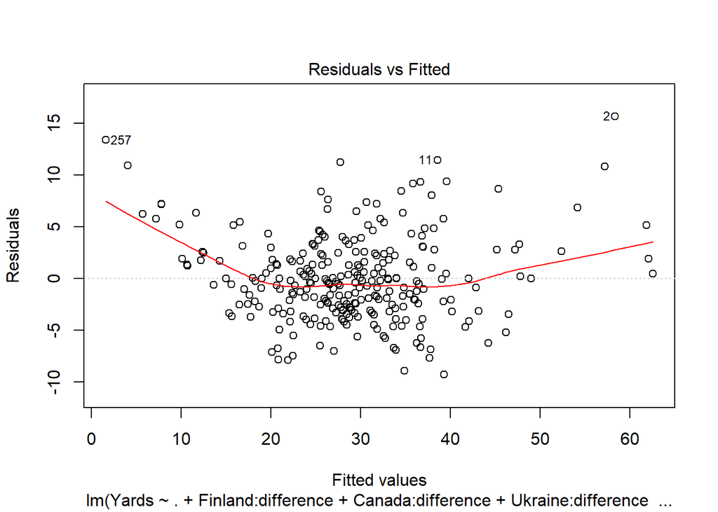

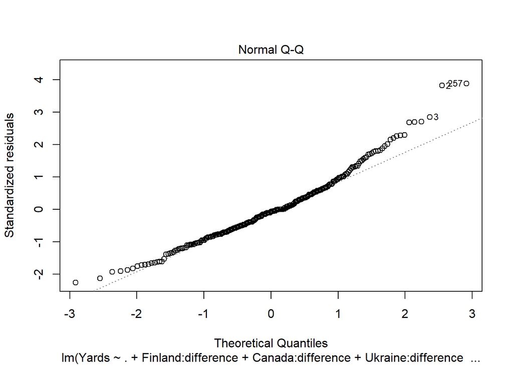

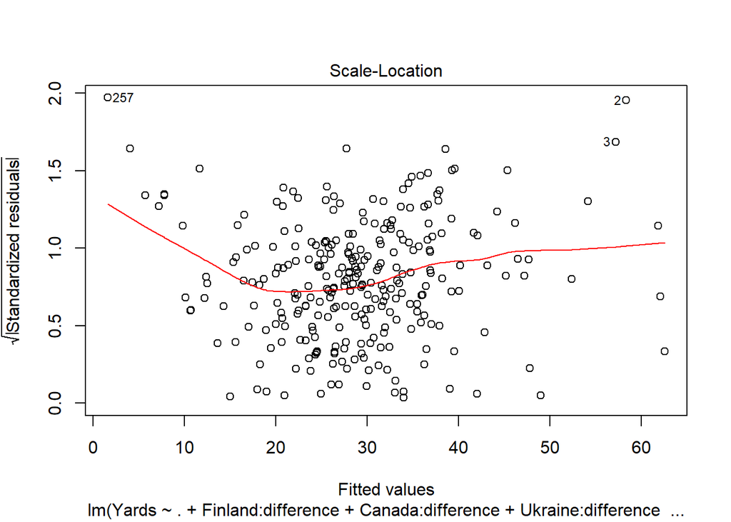

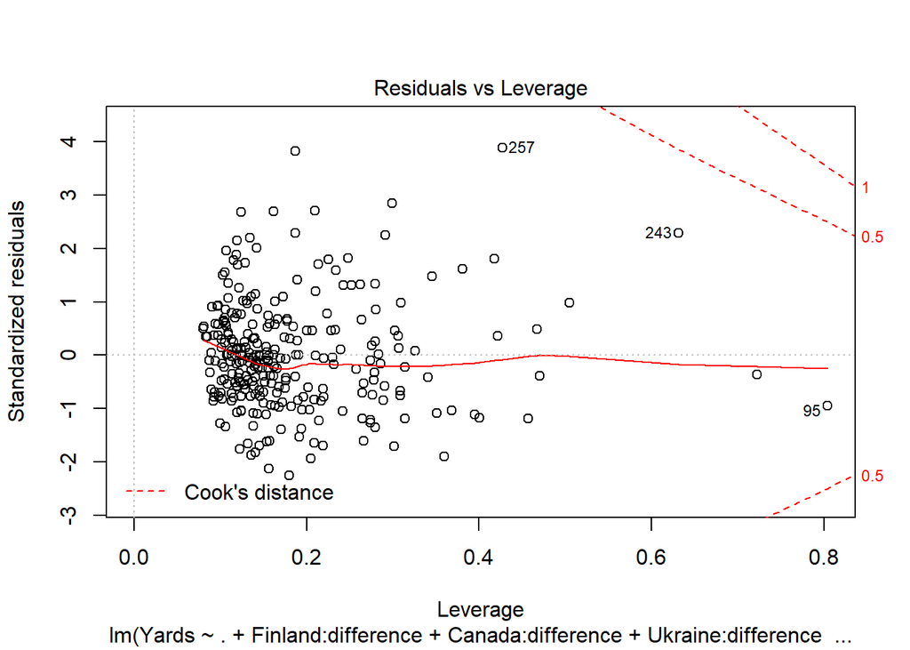

```r
plot(fit.lm.6)
```

```r
df.filtered.2$logy = log(df.filtered.2$Yards)

fit.lm.7 = lm(logy ~ .+
                Finland:difference+
                Canada:difference+
                Ukraine:difference+
                Switzerland:difference+
                Denmark:difference+
                Belgium:difference+
                Ireland:difference+
                UK:difference+
                Germany:difference+
                France:difference+
                NZ:difference+
                US:difference+
                Japan:difference+
                Spain:difference+
                Australia:difference+
                Mexico:difference+
                India:difference+
                Singapore:difference+
                Russia:difference
                - difference
                -Sweden
                -Russia
                - Yards
                -Finland
                -Canada
                -Ukraine
                -Switzerland
                -Denmark
                -Belgium
                -Ireland
                -UK
                -Germany
                -France
                -NZ
                -US
                -Japan
                -Spain
                -Australia
                -Mexico
                -India
                -Singapore
                -Belarus
              ,data = df.filtered.2)
summary(fit.lm.7)
```

```
##
## Call:
## lm(formula = logy ~ . + Finland:difference + Canada:difference +
##     Ukraine:difference + Switzerland:difference + Denmark:difference +
##     Belgium:difference + Ireland:difference + UK:difference +
##     Germany:difference + France:difference + NZ:difference +
##     US:difference + Japan:difference + Spain:difference + Australia:difference +
##     Mexico:difference + India:difference + Singapore:difference +
##     Russia:difference - difference - Sweden - Russia - Yards -
##     Finland - Canada - Ukraine - Switzerland - Denmark - Belgium -
##     Ireland - UK - Germany - France - NZ - US - Japan - Spain -
##     Australia - Mexico - India - Singapore - Belarus, data = df.filtered.2)
##
## Residuals:
##      Min       1Q   Median       3Q      Max
## -0.44894 -0.07860 -0.00285  0.08053  0.40403
##
## Coefficients:
##                           Estimate Std. Error t value Pr(>|t|)
## (Intercept)              3.071e+00  3.162e-01   9.712  < 2e-16 ***
## rate_sd1                -5.546e-04  2.416e-04  -2.296  0.02261 *
## rate_sd2                -2.709e-04  2.912e-04  -0.930  0.35318
## rate_sd3                -4.728e-04  2.563e-04  -1.845  0.06633 .
## rate_sd4                -3.396e-06  1.768e-04  -0.019  0.98469
## avg_rate_q1             -2.794e-04  3.880e-04  -0.720  0.47218
## avg_rate_q2             -2.004e-04  6.917e-04  -0.290  0.77226
## avg_rate_q3             -1.368e-03  6.542e-04  -2.091  0.03761 *
## avg_rate_q4             -1.832e-03  3.621e-04  -5.060 8.63e-07 ***
## median_rate_q1           4.058e-04  2.804e-04   1.447  0.14924
## median_rate_q2           1.213e-05  4.384e-04   0.028  0.97794
## median_rate_q3           4.881e-04  3.572e-04   1.367  0.17312
## median_rate_q4          -2.833e-04  2.493e-04  -1.136  0.25696
## sd_q1                   -5.631e-03  7.220e-04  -7.799 2.22e-13 ***
## sd_q2                   -2.015e-04  6.256e-04  -0.322  0.74768
## sd_q3                   -3.760e-03  6.369e-04  -5.903 1.29e-08 ***
## sd_q4                   -2.321e-03  4.501e-04  -5.157 5.44e-07 ***
## avg_sec_q1              -8.148e-04  4.130e-04  -1.973  0.04972 *
## avg_sec_q2              -3.179e-04  4.209e-04  -0.755  0.45087
## avg_sec_q3              -7.240e-04  3.745e-04  -1.933  0.05443 .
## avg_sec_q4               3.147e-04  3.687e-04   0.854  0.39422
```

[output cut: 21 more lines]

```
## difference:NZ1          -9.361e-03  9.248e-03  -1.012  0.31246
## difference:US1          -7.794e-03  1.227e-02  -0.635  0.52591
## difference:Japan1       -5.257e-03  5.249e-03  -1.001  0.31766
## difference:Spain1       -9.063e-03  1.264e-02  -0.717  0.47416
## difference:Australia1   -7.937e-03  8.957e-03  -0.886  0.37647
## difference:Mexico1      -1.486e-02  1.331e-02  -1.117  0.26518
## difference:India1       -3.532e-03  8.658e-03  -0.408  0.68367
## difference:Singapore1   -9.201e-03  5.209e-03  -1.766  0.07870 .
## difference:Russia1       3.682e-04  4.474e-03   0.082  0.93448
## ---
## Signif. codes:  0 '***' 0.001 '**' 0.01 '*' 0.05 '.' 0.1 ' ' 1
##
## Residual standard error: 0.1459 on 228 degrees of freedom
## Multiple R-squared:  0.8586, Adjusted R-squared:  0.8276
## F-statistic: 27.69 on 50 and 228 DF,  p-value: < 2.2e-16
```

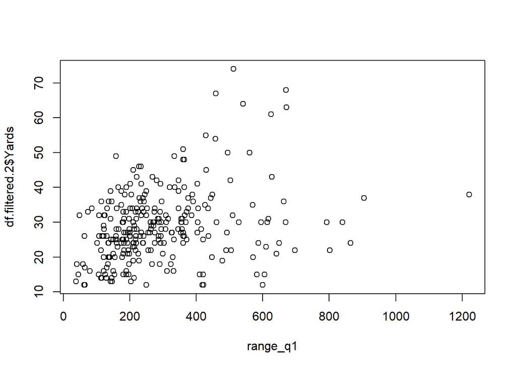

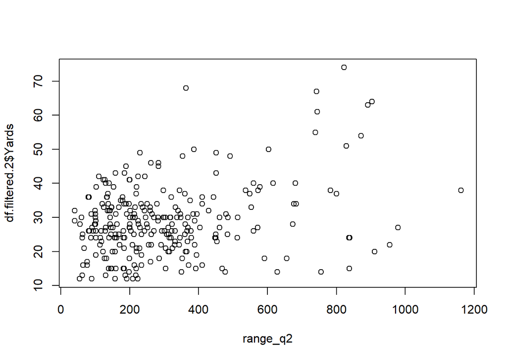

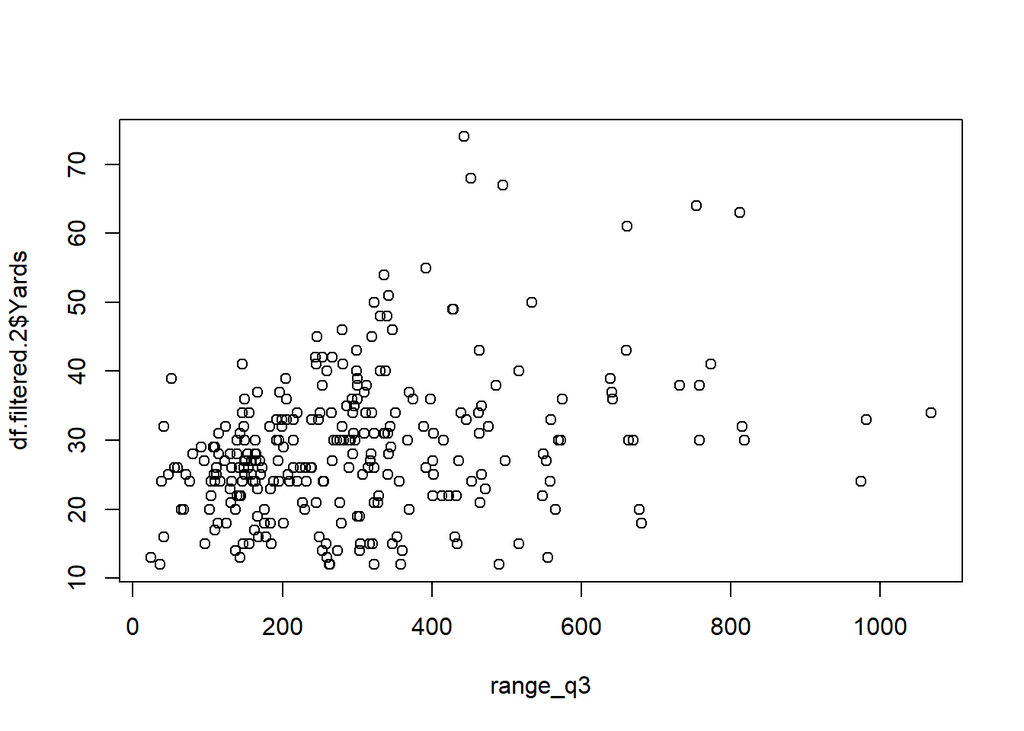

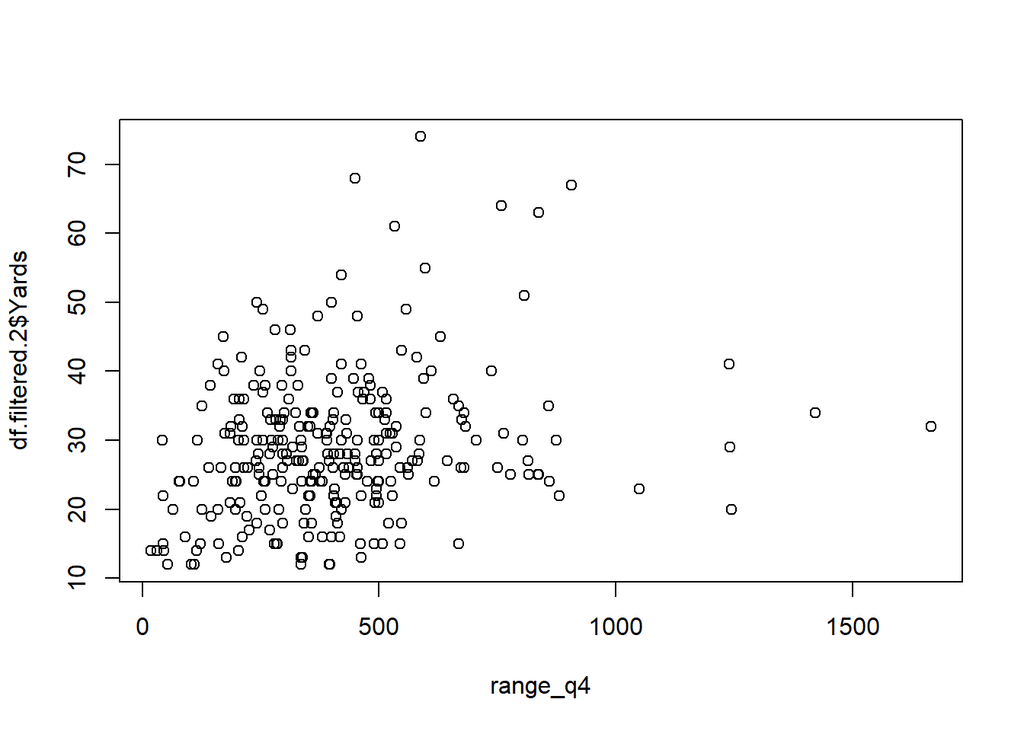

```r
df.filtered.2 = df.filtered.2[-c(94),]
df.filtered.2 = df.filtered.2[-c(124),]

plot(df.filtered.2$Yards ~range_q1+range_q2+range_q3+range_q4,data = df.filtered.2)
```

```r
fit.lm.8 = lm(logy ~ .+
                Finland:difference+
                Canada:difference+
                Ukraine:difference+
                Switzerland:difference+
                Denmark:difference+
                Belgium:difference+
                Ireland:difference+
                UK:difference+
                Germany:difference+
                France:difference+
                NZ:difference+
                US:difference+
                Japan:difference+
                Spain:difference+
                Australia:difference+
                Mexico:difference+
                India:difference+
                Singapore:difference+
                Russia:difference
                - difference
                -Sweden
                -Russia
                -Finland
                -Canada
                -Ukraine
                -Switzerland
                -Denmark
                -Belgium
                -Ireland
                -UK
                -Germany
                -France
                -NZ
                -US
                -Japan
                -Spain
                -Australia
                -Mexico
                - Yards
                -India
                -Singapore
                -Belarus
              ,data = df.filtered.2)
summary(fit.lm.8)
```

```
##
## Call:
## lm(formula = logy ~ . + Finland:difference + Canada:difference +
##     Ukraine:difference + Switzerland:difference + Denmark:difference +
##     Belgium:difference + Ireland:difference + UK:difference +
##     Germany:difference + France:difference + NZ:difference +
##     US:difference + Japan:difference + Spain:difference + Australia:difference +
##     Mexico:difference + India:difference + Singapore:difference +
##     Russia:difference - difference - Sweden - Russia - Finland -
##     Canada - Ukraine - Switzerland - Denmark - Belgium - Ireland -
##     UK - Germany - France - NZ - US - Japan - Spain - Australia -
##     Mexico - Yards - India - Singapore - Belarus, data = df.filtered.2)
##
## Residuals:
##      Min       1Q   Median       3Q      Max
## -0.44937 -0.07921 -0.00052  0.08316  0.39127
##
## Coefficients:
##                           Estimate Std. Error t value Pr(>|t|)
## (Intercept)              3.075e+00  3.165e-01   9.715  < 2e-16 ***
## rate_sd1                -5.696e-04  2.424e-04  -2.350  0.01962 *
## rate_sd2                -2.682e-04  2.928e-04  -0.916  0.36072
## rate_sd3                -4.660e-04  2.573e-04  -1.811  0.07140 .
## rate_sd4                -1.318e-05  1.779e-04  -0.074  0.94103
## avg_rate_q1             -1.632e-04  4.151e-04  -0.393  0.69465
## avg_rate_q2             -2.728e-04  6.953e-04  -0.392  0.69517
## avg_rate_q3             -1.432e-03  6.566e-04  -2.180  0.03027 *
## avg_rate_q4             -1.800e-03  3.859e-04  -4.665 5.28e-06 ***
## median_rate_q1           3.162e-04  2.976e-04   1.062  0.28915
## median_rate_q2           4.864e-05  4.419e-04   0.110  0.91245
## median_rate_q3           5.164e-04  3.597e-04   1.436  0.15244
## median_rate_q4          -2.931e-04  2.497e-04  -1.174  0.24175
## sd_q1                   -5.670e-03  7.254e-04  -7.817 2.04e-13 ***
## sd_q2                   -1.608e-04  6.284e-04  -0.256  0.79826
## sd_q3                   -3.694e-03  6.395e-04  -5.776 2.52e-08 ***
## sd_q4                   -2.287e-03  4.609e-04  -4.962 1.37e-06 ***
## avg_sec_q1              -8.191e-04  4.177e-04  -1.961  0.05114 .
## avg_sec_q2              -2.455e-04  4.264e-04  -0.576  0.56537
## avg_sec_q3              -6.884e-04  3.760e-04  -1.831  0.06846 .
## avg_sec_q4               3.563e-04  3.739e-04   0.953  0.34169
```

[output cut: 21 more lines]

```
## difference:NZ1          -1.046e-02  9.302e-03  -1.125  0.26192
## difference:US1          -9.255e-03  1.234e-02  -0.750  0.45409
## difference:Japan1       -5.315e-03  5.254e-03  -1.012  0.31281
## difference:Spain1       -1.014e-02  1.269e-02  -0.799  0.42522
## difference:Australia1   -9.050e-03  9.014e-03  -1.004  0.31643
## difference:Mexico1      -1.692e-02  1.344e-02  -1.259  0.20943
## difference:India1       -5.423e-03  8.806e-03  -0.616  0.53862
## difference:Singapore1   -9.327e-03  5.214e-03  -1.789  0.07500 .
## difference:Russia1       2.902e-04  4.479e-03   0.065  0.94841
## ---
## Signif. codes:  0 '***' 0.001 '**' 0.01 '*' 0.05 '.' 0.1 ' ' 1
##
## Residual standard error: 0.146 on 226 degrees of freedom
## Multiple R-squared:  0.8595, Adjusted R-squared:  0.8285
## F-statistic: 27.66 on 50 and 226 DF,  p-value: < 2.2e-16
```